# Welcome to the tidyverse

Kate Nelson

1/28/2022

## Objectives

- Learn how to use `dplyr` to clean and wrangle your data.
- Learn how to plot with `ggplot2`

**Acknowledgements**

This tutorial is adapted from Dr. Emily Burchfield’s fantastic tutorial on [Data Management](https://eburchfield.github.io/files/2_describing_data_lab.html).

## Set-up

This tutorial will make use of the `gapminder` package again. Start by loading the package and the `gapminder` data.

```r
library(gapminder)
data(gapminder)
```

You’ll also want to be sure to install and load the `tidyverse` package. This is a suite of packages that includes `dplyr` and `ggplot2`.

```r
library(tidyverse)
```

We already are familiar with this dataset so let’s get right into it.

## Subsetting and more using `dplyr`

The `dplyr`package is one of a number of packages in the `tidyverse` set of packages that makes data wrangling, indexing, and plotting much easier. In this class, we’ll frequently use this set of packages. Yes, you can do the same things using base `R`, but while they may seem a bit trickier initially, the tools in the `tidyverse` are extremely powerful and worth learning. Not convinced? [Check this out](http://varianceexplained.org/r/teach-tidyverse/).

Instead of indexing with `[,]`, `$` and other symbols, `dplyr` contains several functions that make data organization much simpler:

- `select()`: choose columns
- `filter()`: choose rows
- `arrange()`: order or arrange rows
- `mutate()`: create new columns
- `summarize()`: summarize values (for the Brits in the room, you can also use `summarise()`)
- `group_by()`: group observations by a shared value

### Create a `gapminder` subset

Ok, let’s create the same Sri Lanka dataset with year and GDP per capita that we made last week using *base R*, but this time we’ll use `dplyr` code. Don’t forget to load either the `tidyverse` package which contains `dplyr` (`library(tidyverse)`) or just `dplyr` using `library(dplyr)` if you haven’t already:

```r
sri_lanka_gdp <- gapminder %>%
  filter(country == "Sri Lanka") %>%
  select(year, gdpPercap)

head(sri_lanka_gdp)
```

```
## # A tibble: 6 x 2
##    year gdpPercap
##   <int>     <dbl>
## 1  1952     1084.
## 2  1957     1073.
## 3  1962     1074.
## 4  1967     1136.
## 5  1972     1213.
## 6  1977     1349.
```

A few things are happening here. First, you’re probably wondering what that crazy `%>%` thing is. We’ll get there.

So what is the `%>%` thing about? This is called a **pipe**. This allows you to *send* the **output** of one function to the **input** of another.

In this example, we start with the full `gapminder` dataset. We send the **full** dataset into the the `filter()` function, which keeps only rows where the value in the `country` column is `"Sri Lanka"`. We then send this new Sri Lankan data subset into the `select()` function to choose only columns of interest to us. This keeps us from having to create two separate `data.frames` or from complicated indexing (i.e. `c("gdpPercap", "year")`, etc…).

It also is very easy for other `R` programmers to read because it reads like plain old English. (You may see `dplyr` called a “*grammer of data manipulation*”, complete with *verbs* that describe data manipulation actions.) When you write code using `dplyr` structure you can basically read the code as you would a sentence of text.

For example try reading the second block of code in the image below.

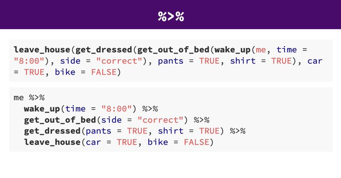

This should read as something like *“I wake up at 8 o’clock, then I get out of bed on the correct side, then I get dressed by putting on pants and a shirt, then I leave the house in my car.”*

Try doing the same with the first block of code… Not happening, right?

Grammatically, I tend to think of the **pipe** as the word **“then”**. Check out [Section 18 of R for Data Science](https://r4ds.had.co.nz/pipes.html) for more on pipes.

Notice that when using `select()` we do not need to use quotes around our column names, `dplyr` already knows that it should be looking for column names, and that they are contained as character strings. We also do not need to provide the name of the dataset in `select()` as in (`gapminder$year`) as `dplyr` knows what dataset we are working with already and will automatically assume you are selecting from that.

### Aggregate subset

Not convinced yet that this trumps base `R`? Ok, say you want to know the average, maximum, and minimum GDP for Sri Lanka over the last 50 years. No problem:

```r
gapminder %>%
  filter(country == "Sri Lanka") %>%
  select(year, gdpPercap) %>%
  summarize(avg_gdp = mean(gdpPercap), max_gdp = max(gdpPercap), min_gdp = min(gdpPercap))
```

```
## # A tibble: 1 x 3
##   avg_gdp max_gdp min_gdp
##     <dbl>   <dbl>   <dbl>
## 1   1855.   3970.   1073.
```

The `summarize()` function takes all rows in each column and applies a function to these rows. `mean(gdpPercap)` takes the mean of all observations of `gdpPercap` for Sri Lanka and returns the average, summarized as the new variable `avg_gdp`.

Try putting this in plain English using the “*grammar of `dplyr`*”. Then unfold the code chunk below to see what I think the code says.

```r
# Start with the gapminder dataset, then filter to only records for the country of Sri Lanka, then remove all columns except for year and gdpPercap, then summarize the Sri Lanka data subset so that we return a dataframe with three newly created columns (avg_gdp, max_gdp, and min_gdp) that describe the average, maximum, and minimum of gdpPercap across all records for Sri Lanka.
```

Let’s go a bit further. Let’s say you want to know which countries have the highest average life expectancy:

```r
gapminder %>%
  group_by(country) %>%
  summarize(mean_le = mean(lifeExp)) %>%
  arrange(desc(mean_le))
```

```
## # A tibble: 142 x 2
##    country     mean_le
##    <fct>         <dbl>
##  1 Iceland        76.5
##  2 Sweden         76.2
##  3 Norway         75.8
##  4 Netherlands    75.6
##  5 Switzerland    75.6
##  6 Canada         74.9
##  7 Japan          74.8
##  8 Australia      74.7
##  9 Denmark        74.4
## 10 France         74.3
## # ... with 132 more rows
```

Notice the use of the `group_by()` function. **This is an important step.**

It groups the data by country (you could also group by year or any other categorical variable) and then applies the function specified in the `summarize()` function to **each group of data**, in our case, to each `country`. We use the function `mean()`, but you can apply any function you can find (or build!) to this grouped data.

So what is `arrange()` doing? It takes as its input the summarized life expectancy dataset, which should contain a column for `country` and a column for `mean_le` and then orders the dataset by values in `mean_le`. `desc()` is another `dplyr` function that just says that a vector should be sorted in *descending* order. To sort in *ascending* order just drop the `desc()` inside the `arrange()` function.

I find the `dplyr` code simpler and much easier to read than answering the same question using *base R*, and this is why we as a class will invest time and energy in learning the ways of the `tidyverse`.

I should add, however, that I’m a big proponent of the **you do you** philosophy, so if you feel strongly attached to *base R* and choose to use *base R* to work with your data, you do you. I’ll also say that on big projects, you tend to use a bit of both, so be sure you’ve reviewed the *base R* resources provided last week.

### Creating variables

What if we want to add a new variable to our dataset? Let’s try recreating the Africa indicator we made last week, but this time using the `mutate()` function in `dplyr`. `mutate()` allows us to easily add new variables to our `dataframe`.

```r
africa <- gapminder %>%
  mutate(africa = ifelse(continent == "Africa", 1, 0))

head(africa)
```

```
## # A tibble: 6 x 7
##   country     continent  year lifeExp      pop gdpPercap africa
##   <fct>       <fct>     <int>   <dbl>    <int>     <dbl>  <dbl>
## 1 Afghanistan Asia       1952    28.8  8425333      779.      0
## 2 Afghanistan Asia       1957    30.3  9240934      821.      0
## 3 Afghanistan Asia       1962    32.0 10267083      853.      0
## 4 Afghanistan Asia       1967    34.0 11537966      836.      0
## 5 Afghanistan Asia       1972    36.1 13079460      740.      0
## 6 Afghanistan Asia       1977    38.4 14880372      786.      0
```

This creates a new `dataframe` to which I’ve *added* a new variable called `africa` that is equal to `1` if the observation is located on the continent of Africa and `0` if it is not. The `ifelse()` function is quite useful, check it out using `?`.

This has been your quick intro to `dplyr`. For more examples of data wrangling and manipulation with `dplyr`, I recommend [this post](http://genomicsclass.github.io/book/pages/dplyr_tutorial.html) as well as the class readings written by the `dplyr` creator and `tidyverse` wizard, Mr.Hadley Wickham.

[figure not shown]

## Plotting using `ggplot2`

Manipulating `dataframes` is all fine and good, but the fun really starts when you start visualizing data. Yet again, the `tidyverse` dominates with a powerful package called `ggplot2`. `ggplot2` makes it easy for you to create beautiful data visualizations. Check out the `ggplot` [gallery](https://www.r-graph-gallery.com/ggplot2-package.html) if you don’t believe me! This lab will give you a very short introduction to `ggplot2`. We’ll spend more time on this package in the following weeks and eventually learn how to plot spatial data with `ggplot2` (and other packages).